# Okesola Moses Olusola EasyVisa Project

**EasyVisa Project**

**Context:**

Business communities in the United States are facing high demand for human resources, but one of the constant challenges is identifying and attracting the right talent, which is perhaps the most important element in remaining competitive. Companies in the United States look for hard-working, talented, and qualified individuals both locally as well as abroad.

The Immigration and Nationality Act (INA) of the US permits foreign workers to come to the United States to work on either a temporary or permanent basis. The act also protects US workers against adverse impacts on their wages or working conditions by ensuring US employers' compliance with statutory requirements when they hire foreign workers to fill workforce shortages. The immigration programs are administered by the Office of Foreign Labor Certification (OFLC).

OFLC processes job certification applications for employers seeking to bring foreign workers into the United States and grants certifications in those cases where employers can demonstrate that there are not sufficient US workers available to perform the work at wages that meet or exceed the wage paid for the occupation in the area of intended employment.

**Objective:**

In FY 2016, the OFLC processed 775,979 employer applications for 1,699,957 positions for temporary and permanent labor certifications. This was a nine percent increase in the overall number of processed applications from the previous year. The process of reviewing every case is becoming a tedious task as the number of applicants is increasing every year.

The increasing number of applicants every year calls for a Machine Learning based solution that can help in shortlisting the candidates having higher chances of VISA approval. OFLC has hired your firm EasyVisa for data-driven solutions. You as a data scientist have to analyze the data provided and, with the help of a classification model:

- Facilitate the process of visa approvals.
- Recommend a suitable profile for the applicants for whom the visa should be certified or denied based on the drivers that significantly influence the case status.

**Data Description**

The data contains the different attributes of the employee and the employer. The detailed data dictionary is given below.

- case_id: ID of each visa application
- continent: Information of continent of the employee
- education_of_employee: Information of education of the employee
- has_job_experience: Does the employee has any job experience? Y= Yes; N = No
- requires_job_training: Does the employee require any job training? Y = Yes; N = No
- no_of_employees: Number of employees in the employer's company
- yr_of_estab: Year in which the employer's company was established
- region_of_employment: Information of foreign worker's intended region of employment in the US.
- prevailing_wage: Average wage paid to similarly employed workers in a specific occupation in the area of intended employment. The purpose of the prevailing wage is to ensure that the foreign worker is not underpaid compared to other workers offering the same or similar service in the same area of employment.
- unit_of_wage: Unit of prevailing wage. Values include Hourly, Weekly, Monthly, and Yearly.
- full_time_position: Is the position of work full-time? Y = Full Time Position; N = Part Time Position
- case_status: Flag indicating if the Visa was certified or denied

## Importing necessary libraries and data

```python
# Installing the libraries with the specified version.
!pip install numpy==1.25.2 pandas==1.5.3 scikit-learn==1.2.2 matplotlib==3.7.1 seaborn==0.13.1 xgboost==2.0.3
```

```python
import warnings

warnings.filterwarnings("ignore")

# Libraries to help with reading and manipulating data
import numpy as np
import pandas as pd

# Library to split data
from sklearn.model_selection import train_test_split

# libaries to help with data visualization
import matplotlib.pyplot as plt
import seaborn as sns

# Removes the limit for the number of displayed columns
pd.set_option("display.max_columns", None)
# Sets the limit for the number of displayed rows
pd.set_option("display.max_rows", 100)


# Libraries different ensemble classifiers
from sklearn.ensemble import (
    BaggingClassifier,
    RandomForestClassifier,
    AdaBoostClassifier,
    GradientBoostingClassifier,
    StackingClassifier,
)

from xgboost import XGBClassifier
from sklearn.tree import DecisionTreeClassifier

# Libraries to get different metric scores
from sklearn import metrics
from sklearn.metrics import (
    confusion_matrix,
    accuracy_score,
    precision_score,
    recall_score,
    f1_score,
)

# To tune different models
from sklearn.model_selection import GridSearchCV
```

**Importing Dataset**

```python
visa_data = pd.read_csv ("EasyVisa.csv" )
```

```python
# copying data to another varaible to avoid any changes to original data
data= visa_data.copy()
```

**Data Overview**

**Checking the first five rows of the data**

```python
data.head()
```

|  | case_id | continent | education_of_employee | has_job_experience | requires_job_training | no_of_employees | yr_of_estab | region_of_employment | prevailing_wage | unit_of_wage | full_time_position | case_status |
| --- | --- | --- | --- | --- | --- | --- | --- | --- | --- | --- | --- | --- |
| 0 | EZYV01 | Asia | High School | N | N | 14513 | 2007 | West | 592.2029 | Hour | Y | Denied |
| 1 | EZYV02 | Asia | Master's | Y | N | 2412 | 2002 | Northeast | 83425.6500 | Year | Y | Certified |
| 2 | EZYV03 | Asia | Bachelor's | N | Y | 44444 | 2008 | West | 122996.8600 | Year | Y | Denied |
| 3 | EZYV04 | Asia | Bachelor's | N | N | 98 | 1897 | West | 83434.0300 | Year | Y | Denied |
| 4 | EZYV05 | Africa | Master's | Y | N | 1082 | 2005 | South | 149907.3900 | Year | Y | Certified |

**Checking the last five rows of the data**

```python
data.tail()
```

|  | case_id | continent | education_of_employee | has_job_experience | requires_job_training | no_of_employees | yr_of_estab | region_of_employment | prevailing_wage | unit_of_wage | full_time_position | case_status |
| --- | --- | --- | --- | --- | --- | --- | --- | --- | --- | --- | --- | --- |
| 25475 | EZYV25476 | Asia | Bachelor's | Y | Y | 2601 | 2008 | South | 77092.57 | Year | Y | Certified |
| 25476 | EZYV25477 | Asia | High School | Y | N | 3274 | 2006 | Northeast | 279174.79 | Year | Y | Certified |
| 25477 | EZYV25478 | Asia | Master's | Y | N | 1121 | 1910 | South | 146298.85 | Year | N | Certified |
| 25478 | EZYV25479 | Asia | Master's | Y | Y | 1918 | 1887 | West | 86154.77 | Year | Y | Certified |
| 25479 | EZYV25480 | Asia | Bachelor's | Y | N | 3195 | 1960 | Midwest | 70876.91 | Year | Y | Certified |

**Understand the shape of the dataset**

```python
data.shape
```

```
(25480, 12)
```

- The dataset has 25480 rows and 12 columns.

**Check the data types of the columns for the dataset**

```python
data.info()
```

```
<class 'pandas.core.frame.DataFrame'>
RangeIndex: 25480 entries, 0 to 25479
Data columns (total 12 columns):
 #   Column                 Non-Null Count  Dtype
---  ------                 --------------  -----
 0   case_id                25480 non-null  object
 1   continent              25480 non-null  object
 2   education_of_employee  25480 non-null  object
 3   has_job_experience     25480 non-null  object
 4   requires_job_training  25480 non-null  object
 5   no_of_employees        25480 non-null  int64
 6   yr_of_estab            25480 non-null  int64
 7   region_of_employment   25480 non-null  object
 8   prevailing_wage        25480 non-null  float64
 9   unit_of_wage           25480 non-null  object
 10  full_time_position     25480 non-null  object
 11  case_status            25480 non-null  object
dtypes: float64(1), int64(2), object(9)
memory usage: 2.3+ MB
```

**Observations**

*There are three numeric columns( two integer and one float type) and nine string( object type) columns in the dataset.

*There are no null values in the dataset..

**Fixing the data types**

```python
# Select columns of object data type excluding 'case_status'
cols = data.select_dtypes(include=['object']).drop('case_status', axis=1)
cols.columns
```

```
Index(['case_id', 'continent', 'education_of_employee', 'has_job_experience',
       'requires_job_training', 'region_of_employment', 'unit_of_wage',
       'full_time_position'],
      dtype='object')
```

```python
for i in cols.columns:
    data[i] = data[i].astype('category')
```

```python
data.info()
```

```
<class 'pandas.core.frame.DataFrame'>
RangeIndex: 25480 entries, 0 to 25479
Data columns (total 12 columns):
 #   Column                 Non-Null Count  Dtype
---  ------                 --------------  -----
 0   case_id                25480 non-null  category
 1   continent              25480 non-null  category
 2   education_of_employee  25480 non-null  category
 3   has_job_experience     25480 non-null  category
 4   requires_job_training  25480 non-null  category
 5   no_of_employees        25480 non-null  int64
 6   yr_of_estab            25480 non-null  int64
 7   region_of_employment   25480 non-null  category
 8   prevailing_wage        25480 non-null  float64
 9   unit_of_wage           25480 non-null  category
 10  full_time_position     25480 non-null  category
 11  case_status            25480 non-null  object
dtypes: category(8), float64(1), int64(2), object(1)
memory usage: 2.2+ MB
```

The memory space has from 2.3+ MB to 2.2+ MB.

**Extract the columns of the dataset**

```python
data.columns
```

```
Index(['case_id', 'continent', 'education_of_employee', 'has_job_experience',
       'requires_job_training', 'no_of_employees', 'yr_of_estab',
       'region_of_employment', 'prevailing_wage', 'unit_of_wage',
       'full_time_position', 'case_status'],
      dtype='object')
```

**Summary of Dataset**

```python
data.describe(include='all').T
```

|  | count | unique | top | freq | mean | std | min | 25% | 50% | 75% | max |
| --- | --- | --- | --- | --- | --- | --- | --- | --- | --- | --- | --- |
| case_id | 25480 | 25480 | EZYV01 | 1 | NaN | NaN | NaN | NaN | NaN | NaN | NaN |
| continent | 25480 | 6 | Asia | 16861 | NaN | NaN | NaN | NaN | NaN | NaN | NaN |
| education_of_employee | 25480 | 4 | Bachelor's | 10234 | NaN | NaN | NaN | NaN | NaN | NaN | NaN |
| has_job_experience | 25480 | 2 | Y | 14802 | NaN | NaN | NaN | NaN | NaN | NaN | NaN |
| requires_job_training | 25480 | 2 | N | 22525 | NaN | NaN | NaN | NaN | NaN | NaN | NaN |
| no_of_employees | 25480.0 | NaN | NaN | NaN | 5667.04321 | 22877.928848 | -26.0 | 1022.0 | 2109.0 | 3504.0 | 602069.0 |
| yr_of_estab | 25480.0 | NaN | NaN | NaN | 1979.409929 | 42.366929 | 1800.0 | 1976.0 | 1997.0 | 2005.0 | 2016.0 |
| region_of_employment | 25480 | 5 | Northeast | 7195 | NaN | NaN | NaN | NaN | NaN | NaN | NaN |
| prevailing_wage | 25480.0 | NaN | NaN | NaN | 74455.814592 | 52815.942327 | 2.1367 | 34015.48 | 70308.21 | 107735.5125 | 319210.27 |
| unit_of_wage | 25480 | 4 | Year | 22962 | NaN | NaN | NaN | NaN | NaN | NaN | NaN |
| full_time_position | 25480 | 2 | Y | 22773 | NaN | NaN | NaN | NaN | NaN | NaN | NaN |
| case_status | 25480 | 2 | Certified | 17018 | NaN | NaN | NaN | NaN | NaN | NaN | NaN |

```python
data.describe(include=['category']).T
```

|  | count | unique | top | freq |
| --- | --- | --- | --- | --- |
| case_id | 25480 | 25480 | EZYV01 | 1 |
| continent | 25480 | 6 | Asia | 16861 |
| education_of_employee | 25480 | 4 | Bachelor's | 10234 |
| has_job_experience | 25480 | 2 | Y | 14802 |
| requires_job_training | 25480 | 2 | N | 22525 |
| region_of_employment | 25480 | 5 | Northeast | 7195 |
| unit_of_wage | 25480 | 4 | Year | 22962 |
| full_time_position | 25480 | 2 | Y | 22773 |

**Let's drop the case_id column: It is a unique identifier**

```python
# drop the Booking_ID column from the dataframe
data= data.drop(columns=["case_id"])
```

**Fixing the negative values in number of employees column**

```python
data.loc[data['no_of_employees'] < 0].shape

# taking the absolute values for number of employees
data["no_of_employees"] = np.abs(data["no_of_employees"])## function to convert the values to a positive number
```

```python
data.describe(include='all').T
```

|  | count | unique | top | freq | mean | std | min | 25% | 50% | 75% | max |
| --- | --- | --- | --- | --- | --- | --- | --- | --- | --- | --- | --- |
| continent | 25480 | 6 | Asia | 16861 | NaN | NaN | NaN | NaN | NaN | NaN | NaN |
| education_of_employee | 25480 | 4 | Bachelor's | 10234 | NaN | NaN | NaN | NaN | NaN | NaN | NaN |
| has_job_experience | 25480 | 2 | Y | 14802 | NaN | NaN | NaN | NaN | NaN | NaN | NaN |
| requires_job_training | 25480 | 2 | N | 22525 | NaN | NaN | NaN | NaN | NaN | NaN | NaN |
| no_of_employees | 25480.0 | NaN | NaN | NaN | 5667.089207 | 22877.917453 | 11.0 | 1022.0 | 2109.0 | 3504.0 | 602069.0 |
| yr_of_estab | 25480.0 | NaN | NaN | NaN | 1979.409929 | 42.366929 | 1800.0 | 1976.0 | 1997.0 | 2005.0 | 2016.0 |
| region_of_employment | 25480 | 5 | Northeast | 7195 | NaN | NaN | NaN | NaN | NaN | NaN | NaN |
| prevailing_wage | 25480.0 | NaN | NaN | NaN | 74455.814592 | 52815.942327 | 2.1367 | 34015.48 | 70308.21 | 107735.5125 | 319210.27 |
| unit_of_wage | 25480 | 4 | Year | 22962 | NaN | NaN | NaN | NaN | NaN | NaN | NaN |
| full_time_position | 25480 | 2 | Y | 22773 | NaN | NaN | NaN | NaN | NaN | NaN | NaN |
| case_status | 25480 | 2 | Certified | 17018 | NaN | NaN | NaN | NaN | NaN | NaN | NaN |

- The negative values for the number of employees have been changed to positive values( minimum value has been changed from -26.0 to 11.0).

**Let's look at the unique values of all the categories**

```python
print(data.continent.value_counts())
print(data.education_of_employee.value_counts())
print(data. has_job_experience.value_counts())
print(data.requires_job_training.value_counts())
print(data.region_of_employment.value_counts())
print(data.unit_of_wage.value_counts())
print(data.full_time_position.value_counts())
print(data.case_status.value_counts())
```

```
Asia             16861
Europe            3732
North America     3292
South America      852
Africa             551
Oceania            192
Name: continent, dtype: int64
Bachelor's     10234
Master's        9634
High School     3420
Doctorate       2192
Name: education_of_employee, dtype: int64
Y    14802
N    10678
Name: has_job_experience, dtype: int64
N    22525
Y     2955
Name: requires_job_training, dtype: int64
Northeast    7195
South        7017
West         6586
Midwest      4307
Island        375
Name: region_of_employment, dtype: int64
Year     22962
Hour      2157
Week       272
Month       89
Name: unit_of_wage, dtype: int64
Y    22773
N     2707
Name: full_time_position, dtype: int64
Certified    17018
Denied        8462
Name: case_status, dtype: int64
```

**Extract all the numerical variables**

```python
# Get the list of all numerical variables
numerical_vars = data.select_dtypes(include=['float64', 'int64']).columns.tolist()

# Print the list of all numerical variables
print("All Numerical Variables:")
for var in numerical_vars:
    print(var)
```

```
All Numerical Variables:
no_of_employees
yr_of_estab
prevailing_wage
```

**Extract all the categorical variables**

```python
# Get the list of all categorical variables
categorical_vars = data.select_dtypes(include=['category']).columns.tolist()

# Print the list of all categorical variables
print("All Categorical Variables:")
for var in categorical_vars:
    print(var)
```

```
All Categorical Variables:
continent
education_of_employee
has_job_experience
requires_job_training
region_of_employment
unit_of_wage
full_time_position
```

**Dataset sanity check**

**Check for duplicate values in the dataset**

```python
data.duplicated().sum()
```

```
0
```

- There are no duplicate values in the dataset.

**Check for missing values in the dataset**

```python
data.isnull().sum()
```

```
continent                0
education_of_employee    0
has_job_experience       0
requires_job_training    0
no_of_employees          0
yr_of_estab              0
region_of_employment     0
prevailing_wage          0
unit_of_wage             0
full_time_position       0
case_status              0
dtype: int64
```

*There are no mising values in the dataset.

## Exploratory Data Analysis (EDA)

- EDA is an important part of any project involving data.
- It is important to investigate and understand the data better before building a model with it.
- A few questions have been mentioned below which will help you approach the analysis in the right manner and generate insights from the data.
- A thorough analysis of the data, in addition to the questions mentioned below, should be done.

**Function to create histogram-boxplot visualization**

```python
# function to create histogram-boxplot visualization

def histogram_boxplot(data, feature, figsize=(15, 10), kde=False, bins=None):
    """
    Boxplot and histogram combined

    data: dataframe
    feature: dataframe column
    figsize: size of figure (default (15,10))
    kde: whether to show the density curve (default False)
    bins: number of bins for histogram (default None)
    """
    f2, (ax_box2, ax_hist2) = plt.subplots(
        nrows=2,  # Number of rows of the subplot grid= 2
        sharex=True,  # x-axis will be shared among all subplots
        gridspec_kw={"height_ratios": (0.25, 0.75)},
        figsize=figsize,
    )  # creating the 2 subplots
    sns.boxplot(
        data=data, x=feature, ax=ax_box2, showmeans=True, color="violet"
    )  # boxplot will be created and a triangle will indicate the mean value of the column
    sns.histplot(
        data=data, x=feature, kde=kde, ax=ax_hist2, bins=bins
    ) if bins else sns.histplot(
        data=data, x=feature, kde=kde, ax=ax_hist2
    )  # For histogram
    ax_hist2.axvline(
        data[feature].mean(), color="green", linestyle="--"
    )  # Add mean to the histogram
    ax_hist2.axvline(
        data[feature].median(), color="black", linestyle="-"
    )  # Add median to the histogram
```

**Function to create labelled barplots**

```python
# function to create labeled barplots


def labeled_barplot(data, feature, perc=False, n=None):
    """
    Barplot with percentage at the top

    data: dataframe
    feature: dataframe column
    perc: whether to display percentages instead of count (default is False)
    n: displays the top n category levels (default is None, i.e., display all levels)
    """

    total = len(data[feature])  # length of the column
    count = data[feature].nunique()
    if n is None:
        plt.figure(figsize=(count + 2, 6))
    else:
        plt.figure(figsize=(n + 2, 6))

    plt.xticks(rotation=90, fontsize=15)
    ax = sns.countplot(
        data=data,
        x=feature,
        order=data[feature].value_counts().index[:n],
    )

    for p in ax.patches:
        if perc == True:
            label = "{:.1f}%".format(
                100 * p.get_height() / total
            )  # percentage of each class of the category
        else:
            label = p.get_height()  # count of each level of the category

        x = p.get_x() + p.get_width() / 2  # width of the plot
        y = p.get_height()  # height of the plot

        ax.annotate(
            label,
            (x, y),
            ha="center",
            va="center",
            size=12,
            xytext=(0, 5),
            textcoords="offset points",
        )  # annotate the percentage

    plt.show()  # show the plot
```

**Data visualization of numerical variables by histogram_boxplot**

**Observation on number of employees**

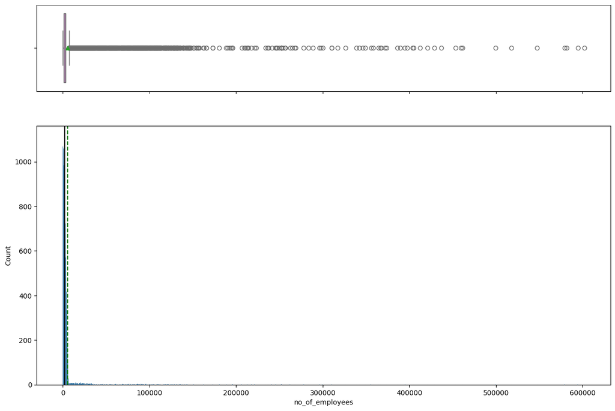

```python
# Plot the histogram and boxplot for amount of RAM
histogram_boxplot(data, "no_of_employees")
```

*The distribution of number of employees is right skewed with some outliers to the right side of the plot.

*There is a need to further analyze the number of employees'column to correct the error of median and the average value close to zero.

**Observation on Year in which the employer's company was established**

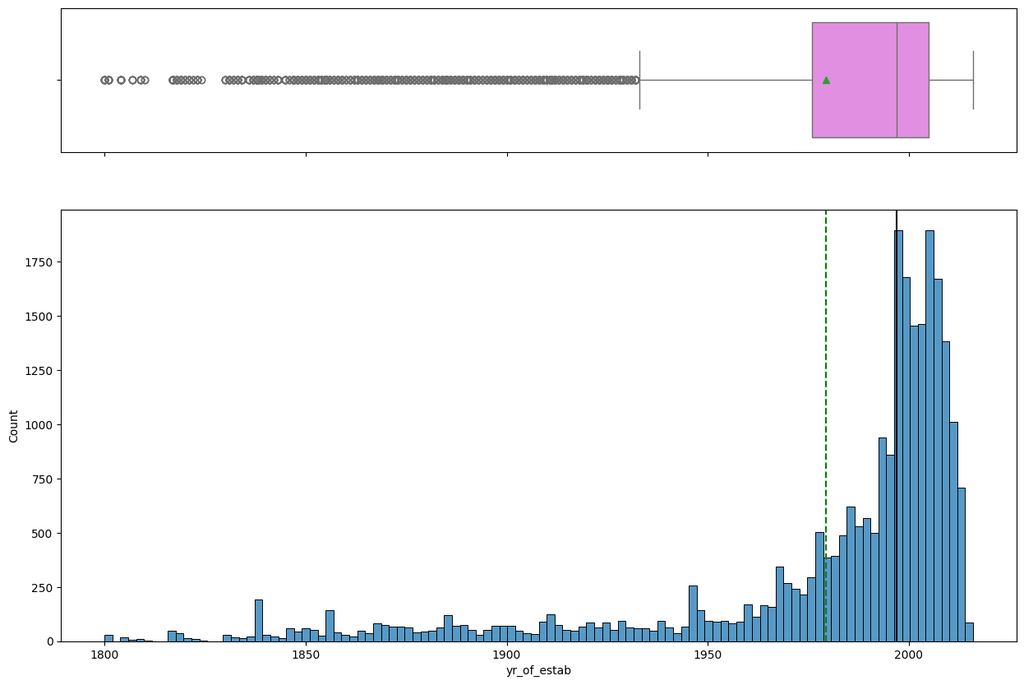

```python
# Plot the histogram and boxplot for amount of RAM
histogram_boxplot(data, "yr_of_estab")
```

**Observation on the prevailing wages**

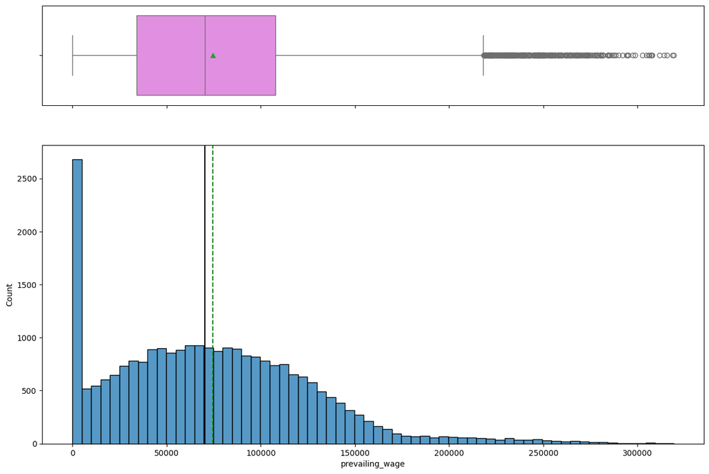

```python
# Plot the histogram and boxplot for amount of RAM
histogram_boxplot(data, "prevailing_wage")
```

- The distribution of the prevailing wages appears normal ,but with many outliers on the right side of the distribution.
- The median and average prevailing wages are close.

**Data visualization of categorical variables by labelled barplot**

**Observation on the case status of employees**

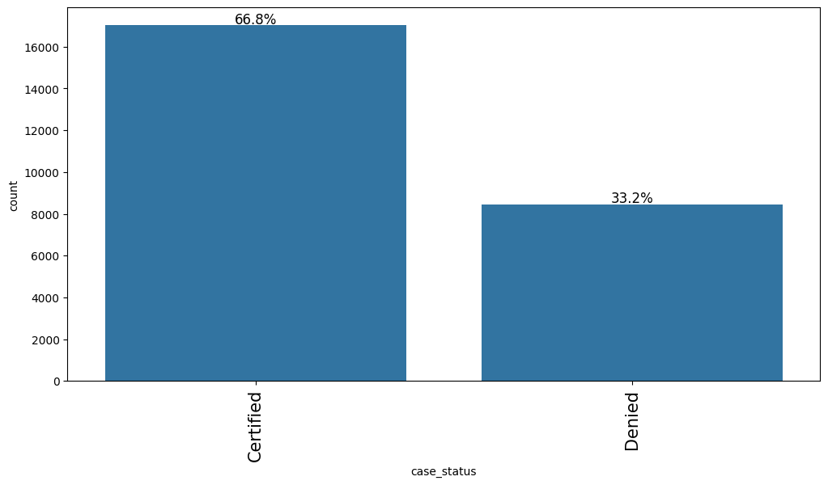

```python
# Plot the labeled barplot for the case status of the employee
labeled_barplot(data, "case_status", perc=True, n=10)
```

- There are 66.8% certified employees and 33.2% denied employees.

**Observation on continent**

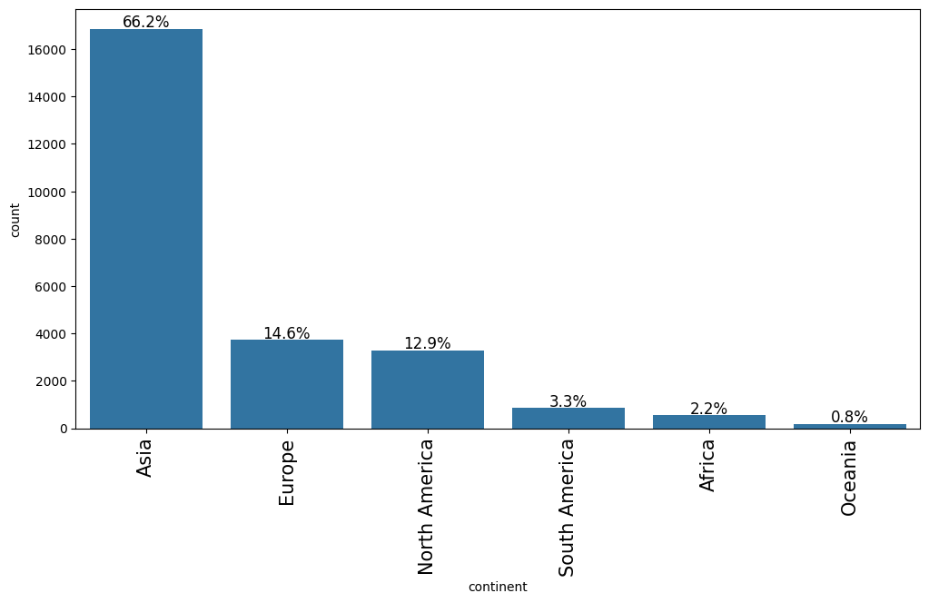

```python
# Plot the labeled barplot for the continent the employee is from
labeled_barplot(data, "continent", perc=True, n=10)
```

- Asia continent has the highest number of employees(66.2%), Europe follows with 14.6%,and the least number of employees(0.8%) come from Oceania.

**Observation on education of Employee**

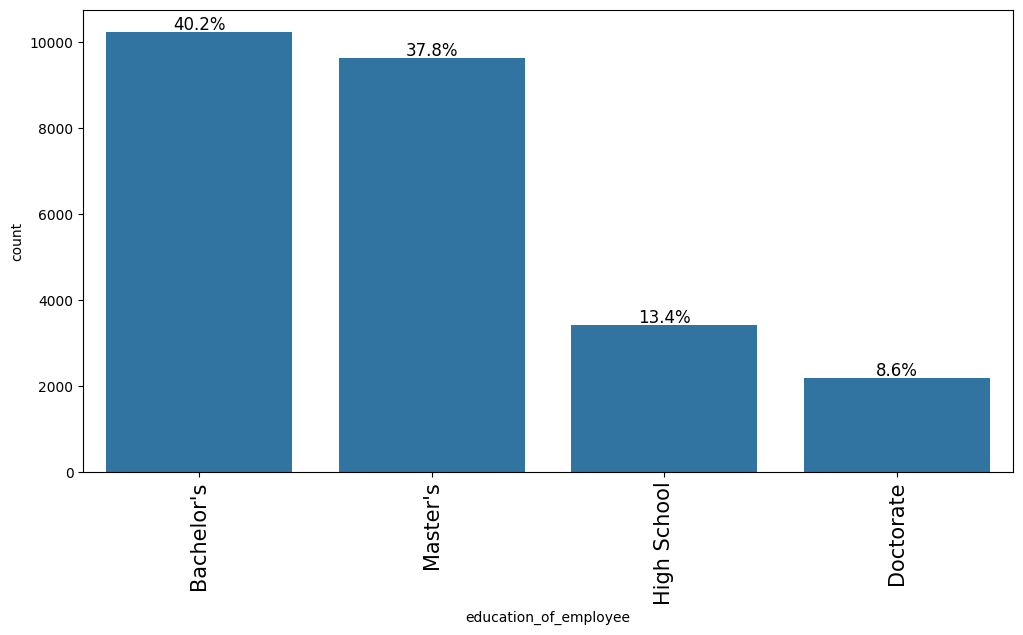

```python
# Plot the labeled barplot for the education of employee
labeled_barplot(data, "education_of_employee", perc=True, n=10)
```

- The number of Bachelor's degree holders among the employees is the highest followed by Master''s, and Doctorate is the least.

**Observation on the job experience of the employee**

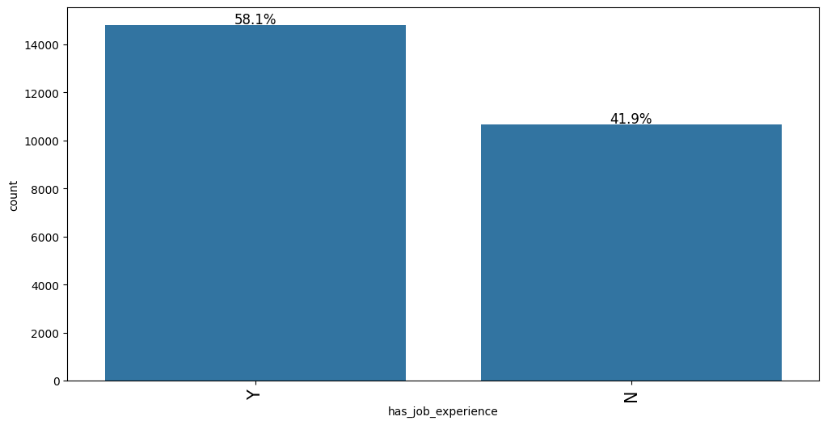

```python
# Plot the labeled barplot for job experience of the employee
labeled_barplot(data, "has_job_experience", perc=True, n=10)
```

- 58.1% of the employees have job experience,and 41.9% of the employees have no job experience.

**Observation on whether an employee requires job training or not**

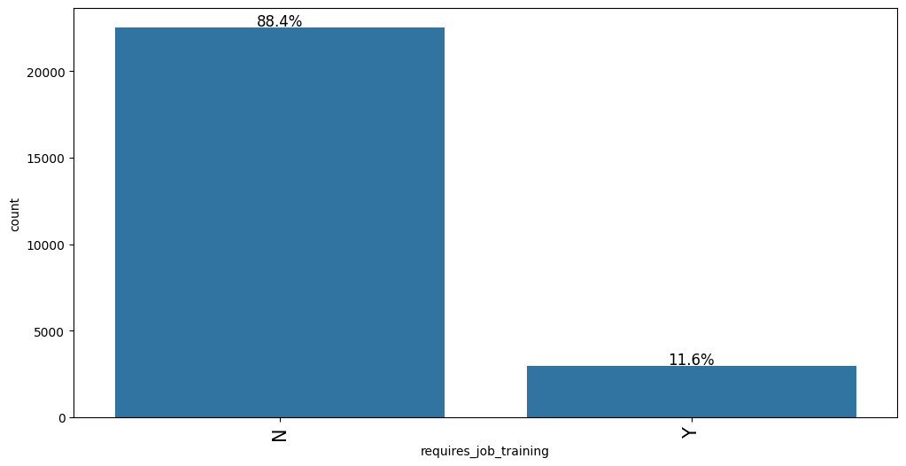

```python
# Plot the labeled barplot on whether an employee requires job training or not
labeled_barplot(data, "requires_job_training", perc=True, n=10)
```

- 11.6% of the employees require job training,and 88.4% of the employees do not require job training.

**Observation on region of employment**

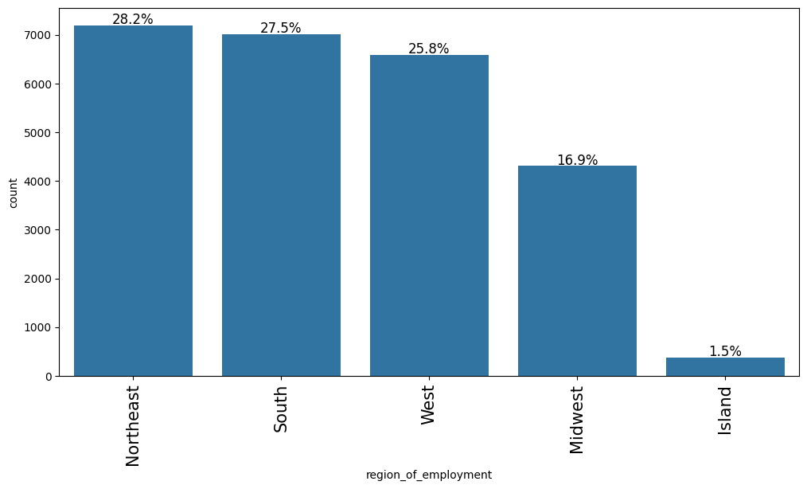

```python
# Plot the labeled barplot for the region of employment
labeled_barplot(data, "region_of_employment", perc=True, n=10)
```

- Information of foreign worker's intended region of employment in the US shows that employees prefer Northeast, South, West, Midwest,and Island in descending order.

**Observation on the unit of wage**

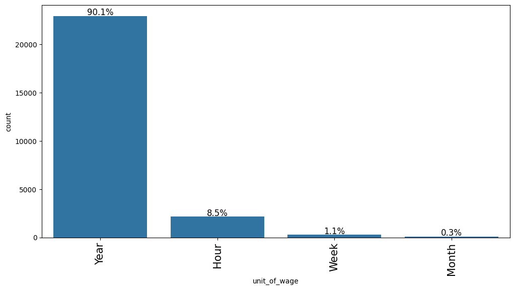

```python
# Plot the labeled barplot for the unit of employee's wage
labeled_barplot(data, "unit_of_wage", perc=True, n=10)
```

- Yearly unit of prevailing wages for the employees is ~90% and mostly common, monthly unit of prevailing wages is the least.

**Observation on position of work**

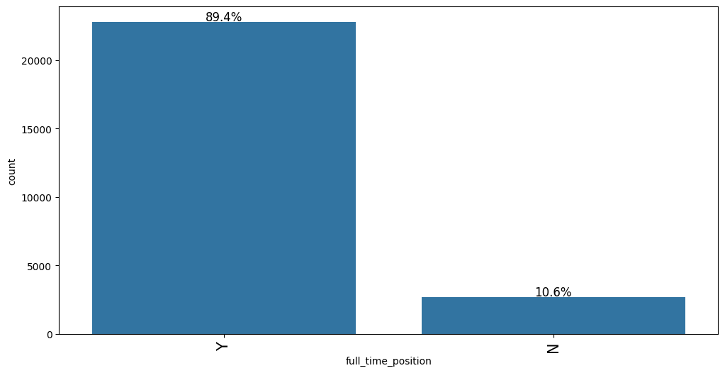

```python
# Plot the labeled barplot for the postion of work
labeled_barplot(data, "full_time_position", perc=True, n=10)
```

- ~89% of employees are working or want to work full-time while ~11% of the employees are not working or do not want to work full-time.

**Bivariate Analysis**

**Correlation check among numerical variables**

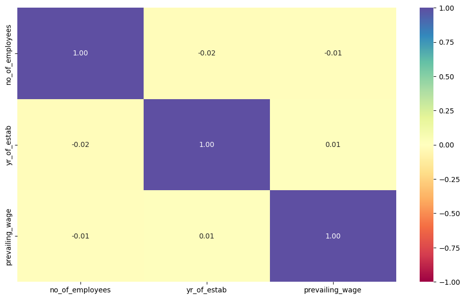

```python
cols_list = data.select_dtypes(include=np.number).columns.tolist()

plt.figure(figsize=(12, 7))
sns.heatmap(data[cols_list].corr(), annot=True, vmin=-1, vmax=1, fmt=".2f", cmap="Spectral")
plt.show()
```

- There is a very weak, and negative correlation between number of employees and prevailing wage as well as year of company's establishment.

**Leading Questions**:

1. Those with higher education may want to travel abroad for a well-paid job. Does education play a role in Visa certification?
2. How does the visa status vary across different continents?
3. Experienced professionals might look abroad for opportunities to improve their lifestyles and career development. Does work experience influence visa status?
4. In the United States, employees are paid at different intervals. Which pay unit is most likely to be certified for a visa?
5. The US government has established a prevailing wage to protect local talent and foreign workers. How does the visa status change with the prevailing wage?

**Creating functions that will help us with further analysis**

```python
### function to plot distributions wrt target


def distribution_plot_wrt_target(data, predictor, target):

    fig, axs = plt.subplots(2, 2, figsize=(12, 10))

    target_uniq = data[target].unique()

    axs[0, 0].set_title("Distribution of target for target=" + str(target_uniq[0]))
    sns.histplot(
        data=data[data[target] == target_uniq[0]],
        x=predictor,
        kde=True,
        ax=axs[0, 0],
        color="teal",
        stat="density",
    )

    axs[0, 1].set_title("Distribution of target for target=" + str(target_uniq[1]))
    sns.histplot(
        data=data[data[target] == target_uniq[1]],
        x=predictor,
        kde=True,
        ax=axs[0, 1],
        color="orange",
        stat="density",
    )

    axs[1, 0].set_title("Boxplot w.r.t target")
    sns.boxplot(data=data, x=target, y=predictor, ax=axs[1, 0])

    axs[1, 1].set_title("Boxplot (without outliers) w.r.t target")
    sns.boxplot(
        data=data,
        x=target,
        y=predictor,
        ax=axs[1, 1],
        showfliers=False,
    )

    plt.tight_layout()
    plt.show()
```

```python
def stacked_barplot(data, predictor, target):
    """
    Print the category counts and plot a stacked bar chart

    data: dataframe
    predictor: independent variable
    target: target variable
    """
    count = data[predictor].nunique()
    sorter = data[target].value_counts().index[-1]
    tab1 = pd.crosstab(data[predictor], data[target], margins=True).sort_values(
        by=sorter, ascending=False
    )
    print(tab1)
    print("-" * 120)
    tab = pd.crosstab(data[predictor], data[target], normalize="index").sort_values(
        by=sorter, ascending=False
    )
    tab.plot(kind="bar", stacked=True, figsize=(count + 5, 5))
    plt.legend(
        loc="lower left", frameon=False,
    )
    plt.legend(loc="upper left", bbox_to_anchor=(1, 1))
    plt.show()
```

**Does education play a role in Visa certification?**

```
case_status            Certified  Denied    All
education_of_employee
All                        17018    8462  25480
Bachelor's                  6367    3867  10234
High School                 1164    2256   3420
Master's                    7575    2059   9634
Doctorate                   1912     280   2192
------------------------------------------------------------------------------------------------------------------------
```

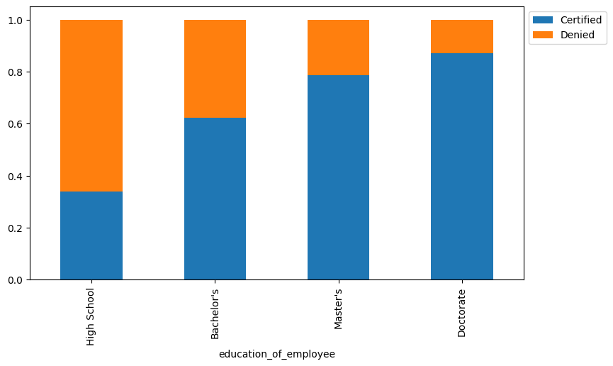

```python
stacked_barplot(data, "education_of_employee", "case_status")
```

**How does the visa status vary across different continents?**

```
case_status    Certified  Denied    All
continent
All                17018    8462  25480
Asia               11012    5849  16861
North America       2037    1255   3292
Europe              2957     775   3732
South America        493     359    852
Africa               397     154    551
Oceania              122      70    192
------------------------------------------------------------------------------------------------------------------------
```

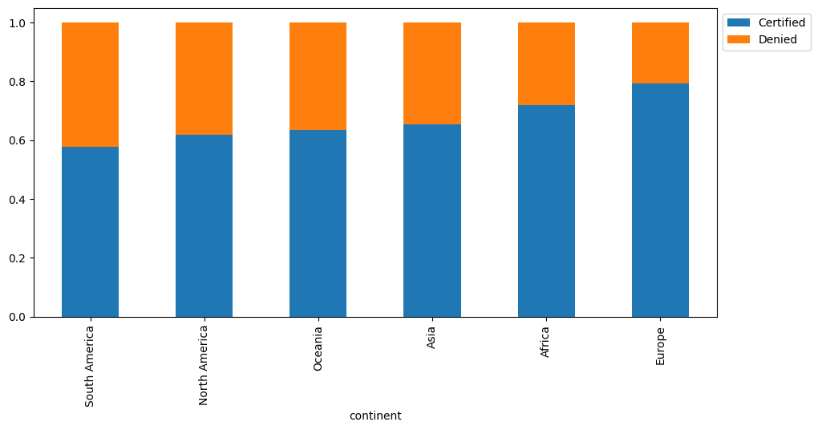

```python
# Plot approval rate by continent
stacked_barplot(data, 'continent', 'case_status')
```

**Does work experience influence visa status?**

```
case_status         Certified  Denied    All
has_job_experience
All                     17018    8462  25480
N                        5994    4684  10678
Y                       11024    3778  14802
------------------------------------------------------------------------------------------------------------------------
```

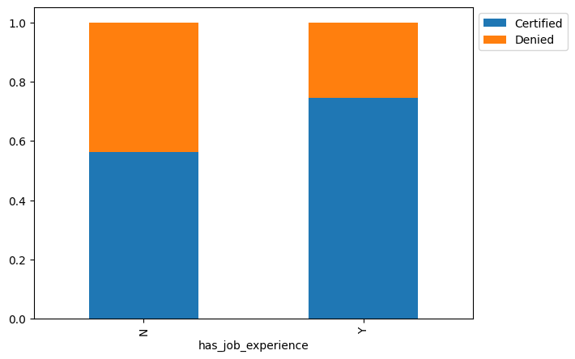

```python
# Plot approval rate based on job experience
stacked_barplot(data, 'has_job_experience', 'case_status')
```

**Which pay unit is most likely to be certified for a visa in the United States?**

```
case_status   Certified  Denied    All
unit_of_wage
All               17018    8462  25480
Year              16047    6915  22962
Hour                747    1410   2157
Week                169     103    272
Month                55      34     89
------------------------------------------------------------------------------------------------------------------------
```

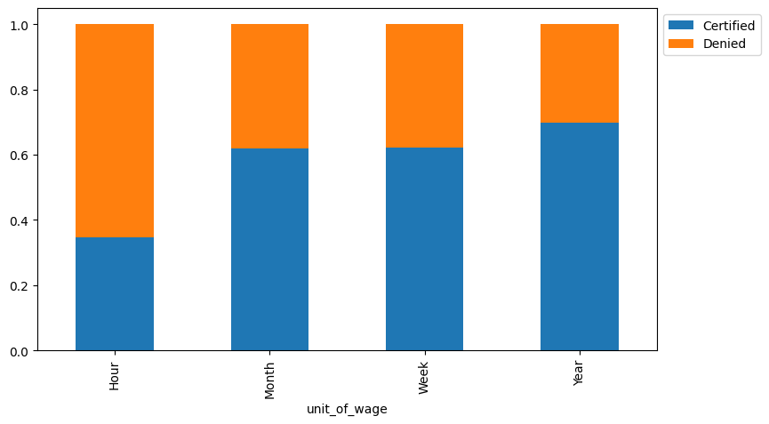

```python
# Plot approval rate by unit_of_wage
stacked_barplot(data, 'unit_of_wage', 'case_status')
```

**How does the visa status change with the prevailing wage in the US?**

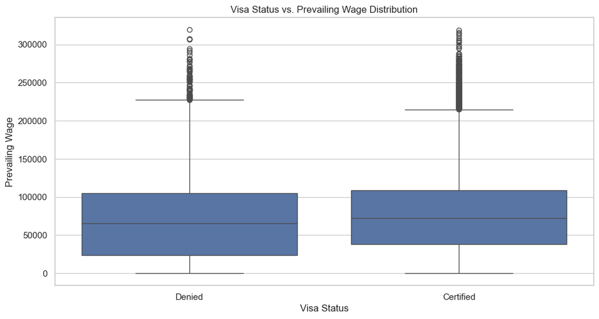

```python
# Set the style of the plots
sns.set(style="whitegrid")

# Create a box plot to visualize the distribution of prevailing wage by visa status
plt.figure(figsize=(12, 6))
sns.boxplot(x='case_status', y='prevailing_wage', data=data)
plt.title('Visa Status vs. Prevailing Wage Distribution')
plt.xlabel('Visa Status')
plt.ylabel('Prevailing Wage')
plt.show()
```

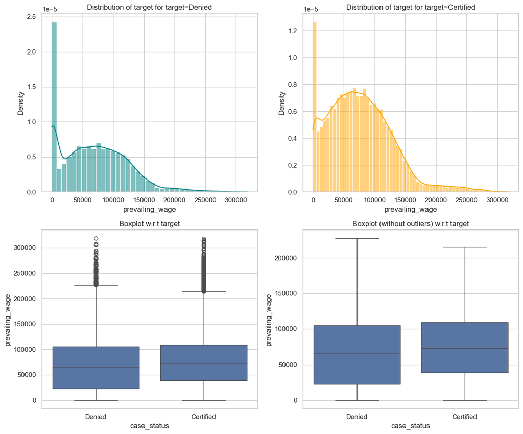

```python
distribution_plot_wrt_target(data, 'prevailing_wage', 'case_status') ## the code to find distribution of prevailing wage and case status
```

- The distribution of prevailing wage with employees' visa status shows a pattern that suggests a peaked distribution with a gradual decrease in frequency away from the peak(s) and a relatively spread-out distribution in certain regions.
- The median prevailing wage of certified employees is higher than that of denied employees in the plot with and without outliers.
- The maximum prevailing wage of denied employees is higher than that of certified employees.
- The miniimum prevailing wage of denied employees is the same with that of certified employees.

**Plot of requires_job_training vs. case_status**

```
case_status            Certified  Denied    All
requires_job_training
All                        17018    8462  25480
N                          15012    7513  22525
Y                           2006     949   2955
------------------------------------------------------------------------------------------------------------------------
```

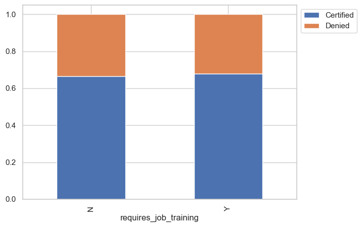

```python
# Plot of relationship between  case status and whether an employee requires job training
stacked_barplot(data, 'requires_job_training', 'case_status')
```

**Plot of full_time_position vs case_status**

```
case_status         Certified  Denied    All
full_time_position
All                     17018    8462  25480
Y                       15163    7610  22773
N                        1855     852   2707
------------------------------------------------------------------------------------------------------------------------
```

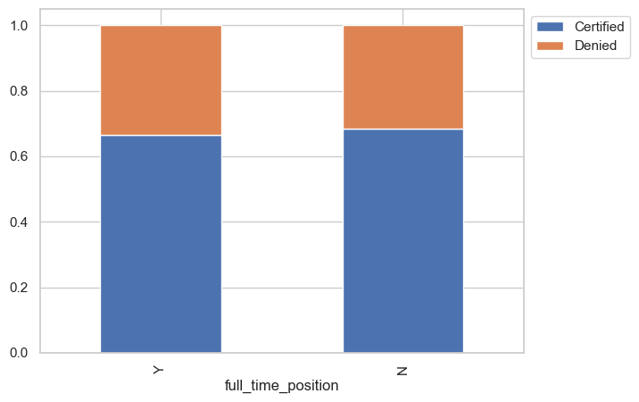

```python
# Plot of relationship between case status and whether an employee requires full time position
stacked_barplot(data, 'full_time_position', 'case_status')
```

- The number of visa approval given to employees who requested for full time position and employees who did not request for it is very close.
- The employees with full time position's request received more visa approval than employees that requested not.

**Plot of no_of_employees vs. case_status**

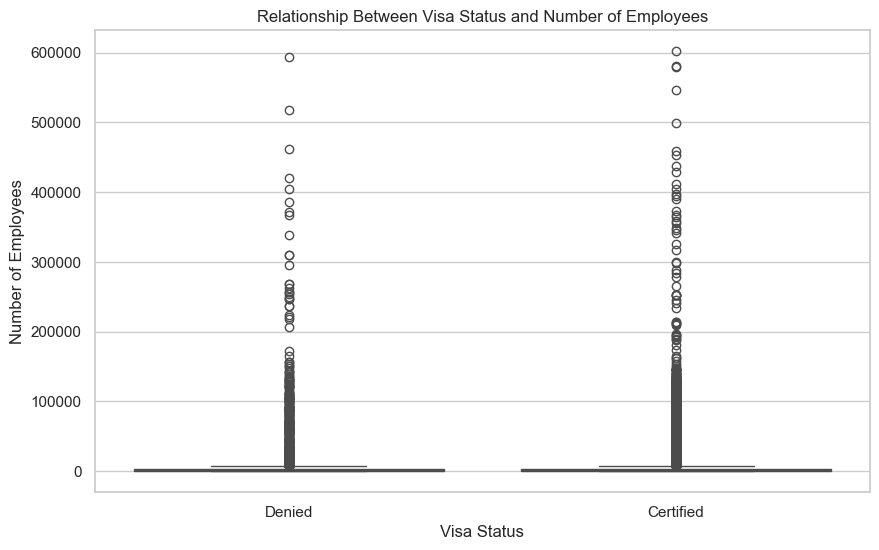

```python
# Plot of relationship between case status and whether an employee prefers full time position
# Create a boxplot to visualize the relationship between two categorical variables
plt.figure(figsize=(10, 6))
sns.boxplot(x='case_status', y='no_of_employees',data=data)
plt.title('Relationship Between Visa Status and Number of Employees')
plt.xlabel('Visa Status')
plt.ylabel('Number of Employees')
plt.show()
```

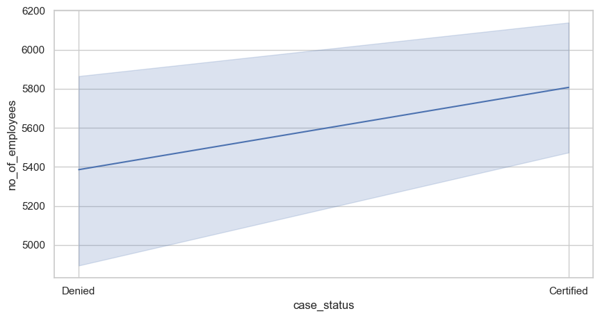

```python
plt.figure(figsize=(10, 5))
sns.lineplot(data, x='case_status', y='no_of_employees')
plt.show()
```

- There is no distinctive relationship between number of employees and the the case status.
- Meanwhile, the number of employees with certified visa status is higher than number of employees of denied visa status.

**Plot of yr_of_estab vs. case_status**

```python
# Plot of relationship between case status and year of company's establishment
stacked_barplot(data, 'yr_of_estab', 'case_status')
```

```
case_status  Certified  Denied    All
yr_of_estab
All              17018    8462  25480
1998               736     398   1134
2001               656     361   1017
2005               719     332   1051
2007               682     312    994
...                ...     ...    ...
1822                 3       1      4
1820                 5       1      6
1842                 5       1      6
1810                 3       0      3
1846                 4       0      4

[200 rows x 3 columns]
------------------------------------------------------------------------------------------------------------------------
```

[figure not shown]

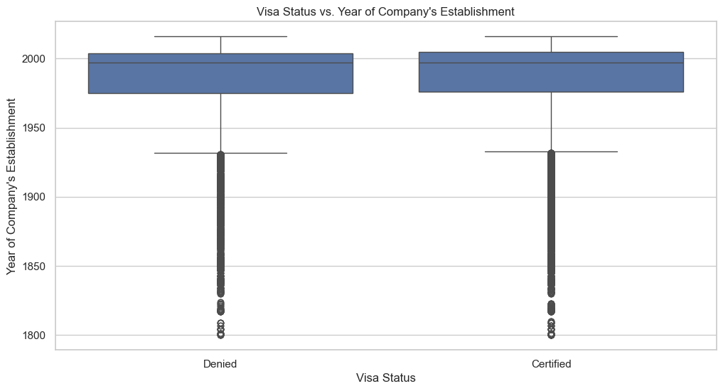

```python
# Set the style of the plots
sns.set(style="whitegrid")

# Create a box plot to visualize the distribution of year of company's establishment by visa status
plt.figure(figsize=(12, 6))
sns.boxplot(x='case_status', y='yr_of_estab', data=data)
plt.title("Visa Status vs. Year of Company's Establishment")
plt.xlabel('Visa Status')
plt.ylabel("Year of Company's Establishment")
plt.show()
```

- The year of establishment of the companies that employed the workers has no visible relationship with their visa status.

**Plot of region_of_employment vs. case_status**

```
case_status           Certified  Denied    All
region_of_employment
All                       17018    8462  25480
Northeast                  4526    2669   7195
West                       4100    2486   6586
South                      4913    2104   7017
Midwest                    3253    1054   4307
Island                      226     149    375
------------------------------------------------------------------------------------------------------------------------
```

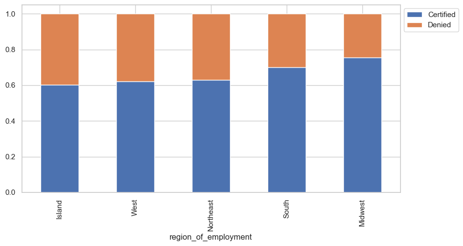

```python
# Plot of relationship between case status and region of employment
stacked_barplot(data, 'region_of_employment', 'case_status')
```

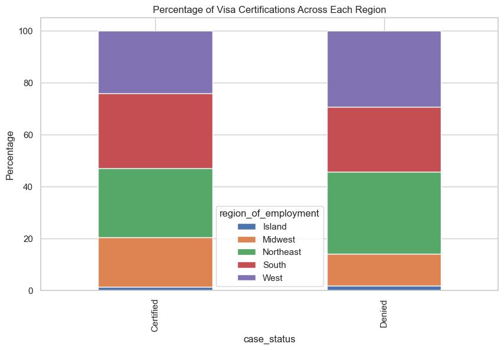

```python
def stacked_barplot(data, case_status, region_of_employment):
    # Create a crosstab between the 'case_status' and 'region_of_employment' columns
    ct = pd.crosstab(data[case_status], data[region_of_employment], normalize='index') * 100  # Calculate percentages across the index axis

    # Plot the stacked bar plot
    ct.plot(kind='bar', stacked=True, figsize=(10, 6))
    plt.ylabel("Percentage")
    plt.title("Percentage of Visa Certifications Across Each Region")
    plt.show()

# Call the function with 'case_status' and 'region_of_employment'
stacked_barplot(data, 'case_status', 'region_of_employment')
```

**Plot of region_of_employment vs. education_of_employee**

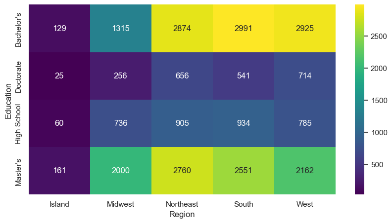

```python
plt.figure(figsize=(10, 5))
sns.heatmap(pd.crosstab(data['education_of_employee'], data['region_of_employment']),
    annot=True,
    fmt="g",
    cmap="viridis"
) ## Complete the code to plot heatmap for the crosstab between education and region of employment

plt.ylabel("Education")
plt.xlabel("Region")
plt.show()
```

- Northeast Region has highest number of employees with Master's degree followed by the South Region, and the least is Island Region.
- South Region has highest number of employees with Bachelor's degree followed by the West Region, and the least is Island Region.
- West Region has highest number of employees with Doctorate's degree followed by the Northeast Region, and the least is Island Region.
- South Region has highest number of employees with High School's degree followed by the Northeast Region, and the least is Island Region.

**Plot of requires_job_training vs. has_job_experience**

[figure not shown]

```python
stacked_barplot(data, 'requires_job_training','has_job_experience') ## the code to plot stacked barplot for job experience and requires_job_training
```

## Data Preprocessing

- Missing value treatment (if needed)
- Feature engineering
- Outlier detection and treatment (if needed)
- Preparing data for modeling
- Any other preprocessing steps (if needed)

**Store the original dataset in another dataframe to avoid changes to original set**

```python
df= data.copy()
```

**Outlier Detection and Treatment**

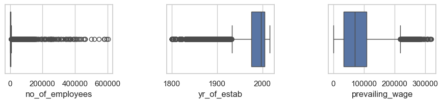

```python
# outlier detection using boxplot
num_cols = df.select_dtypes(include=np.number).columns.tolist()

plt.figure(figsize=(15, 15))

for i, variable in enumerate(num_cols):
    plt.subplot(6, 4, i + 1)
    sns.boxplot(data=df, x=variable)

plt.subplots_adjust(wspace=0.5, hspace=0.5)  # Adjust the space between subplots

plt.show()
```

- There are quite sustantial outliers in the data.

However, we will not treat them as they are proper values.

**Feature Enginnering**

**Handling Categorical Variables: Convert categorical variables into numerical format using one-hot encoding or label encoding.**

```python
from sklearn.preprocessing import LabelEncoder

# Initialize LabelEncoder
label_encoder = LabelEncoder()

# Encode the categorical variables

# Perform label encoding for each categorical column
for col in["continent", "education_of_employee","region_of_employment", "unit_of_wage","requires_job_training","has_job_experience","full_time_position"]:
    df[col] = label_encoder.fit_transform(df[col])

df["continent_encoded"] = label_encoder.fit_transform(df["continent"])
df["education_of_employee_encoded"] = label_encoder.fit_transform(df["education_of_employee"])
df["requires_job_training_encoded"] = label_encoder.fit_transform(df["requires_job_training"])
df["has_job_experience_encoded"] = label_encoder.fit_transform(df["has_job_experience"])
df["full_time_position_encoded"] = label_encoder.fit_transform(df["full_time_position"])
df["unit_of_wage_encoded"] = label_encoder.fit_transform(df["requires_job_training"])
df["region_of_employment_encoded"] = label_encoder.fit_transform(df["requires_job_training"])
```

```python
df.describe().T
```

|  | count | mean | std | min | 25% | 50% | 75% | max |
| --- | --- | --- | --- | --- | --- | --- | --- | --- |
| continent | 25480.0 | 1.539600 | 0.998292 | 0.0000 | 1.00 | 1.00 | 2.0000 | 5.00 |
| education_of_employee | 25480.0 | 1.488776 | 1.345155 | 0.0000 | 0.00 | 2.00 | 3.0000 | 3.00 |
| has_job_experience | 25480.0 | 0.580926 | 0.493417 | 0.0000 | 0.00 | 1.00 | 1.0000 | 1.00 |
| requires_job_training | 25480.0 | 0.115973 | 0.320199 | 0.0000 | 0.00 | 0.00 | 0.0000 | 1.00 |
| no_of_employees | 25480.0 | 5667.089207 | 22877.917453 | 11.0000 | 1022.00 | 2109.00 | 3504.0000 | 602069.00 |
| yr_of_estab | 25480.0 | 1979.409929 | 42.366929 | 1800.0000 | 1976.00 | 1997.00 | 2005.0000 | 2016.00 |
| region_of_employment | 25480.0 | 2.593878 | 1.088376 | 0.0000 | 2.00 | 3.00 | 4.0000 | 4.00 |
| prevailing_wage | 25480.0 | 74455.814592 | 52815.942327 | 2.1367 | 34015.48 | 70308.21 | 107735.5125 | 319210.27 |
| unit_of_wage | 25480.0 | 2.728375 | 0.844267 | 0.0000 | 3.00 | 3.00 | 3.0000 | 3.00 |
| full_time_position | 25480.0 | 0.893760 | 0.308151 | 0.0000 | 1.00 | 1.00 | 1.0000 | 1.00 |
| continent_encoded | 25480.0 | 1.539600 | 0.998292 | 0.0000 | 1.00 | 1.00 | 2.0000 | 5.00 |
| education_of_employee_encoded | 25480.0 | 1.488776 | 1.345155 | 0.0000 | 0.00 | 2.00 | 3.0000 | 3.00 |
| requires_job_training_encoded | 25480.0 | 0.115973 | 0.320199 | 0.0000 | 0.00 | 0.00 | 0.0000 | 1.00 |
| has_job_experience_encoded | 25480.0 | 0.580926 | 0.493417 | 0.0000 | 0.00 | 1.00 | 1.0000 | 1.00 |
| full_time_position_encoded | 25480.0 | 0.893760 | 0.308151 | 0.0000 | 1.00 | 1.00 | 1.0000 | 1.00 |
| unit_of_wage_encoded | 25480.0 | 0.115973 | 0.320199 | 0.0000 | 0.00 | 0.00 | 0.0000 | 1.00 |
| region_of_employment_encoded | 25480.0 | 0.115973 | 0.320199 | 0.0000 | 0.00 | 0.00 | 0.0000 | 1.00 |

**Temporal Features: Extract temporal feature like 'age_of_company from 'yr_of_estab' to capture the age of the company.**

```python
# extract the years of establishment of companies

df.yr_of_estab.unique()
```

```
array([2007, 2002, 2008, 1897, 2005, 2012, 1994, 1924, 1995, 2004, 1963,
       2006, 1987, 1991, 2001, 1972, 2013, 1968, 1884, 1981, 1997, 2009,
       1998, 1880, 2000, 2010, 1965, 1909, 2011, 1989, 1933, 1960, 2003,
       1976, 1996, 1847, 1935, 1890, 1999, 1838, 1947, 1939, 1970, 1977,
       1982, 1943, 1956, 1864, 1974, 1985, 1984, 1971, 1913, 1969, 1818,
       1839, 1914, 1988, 1944, 1855, 1975, 1966, 1801, 1920, 1925, 1993,
       1992, 1979, 1986, 1931, 1962, 1954, 1868, 1859, 1946, 1950, 1869,
       1917, 2014, 1980, 1896, 1949, 1843, 1850, 1906, 1961, 1951, 1958,
       1912, 1983, 1948, 1945, 1978, 1898, 1923, 1911, 1851, 1865, 1849,
       1872, 1967, 1926, 1873, 1848, 2015, 1889, 1876, 1852, 1938, 1973,
       1959, 1927, 1990, 1930, 1922, 1940, 1878, 1934, 1834, 1928, 1800,
       1861, 1952, 1846, 1885, 1907, 1817, 1841, 1821, 1953, 1888, 1916,
       1886, 2016, 1932, 1915, 1937, 1866, 1919, 1921, 1910, 1854, 1875,
       1904, 1879, 1942, 1964, 1899, 1900, 1837, 1887, 1929, 1936, 1857,
       1877, 1918, 1902, 1804, 1823, 1893, 1908, 1833, 1941, 1867, 1836,
       1871, 1881, 1840, 1957, 1856, 1845, 1863, 1955, 1858, 1874, 1892,
       1853, 1894, 1883, 1860, 1819, 1905, 1831, 1882, 1870, 1901, 1895,
       1824, 1862, 1807, 1832, 1822, 1903, 1810, 1820, 1809, 1891, 1830,
       1842], dtype=int64)
```

```python
# Calculate the current year dynamically based on the dataset
current_year = df['yr_of_estab'].max()  # Assuming 'yr_of_estab' represents the current year in the dataset
print(current_year)
```

```
2016
```

```python
# Proceed with the rest of the code using df_new DataFrame
df['age_of_company'] = current_year - df['yr_of_estab']
df.drop("yr_of_estab", axis=1, inplace=True)

age_stats = df["age_of_company"].describe()
print(age_stats)
```

```
count    25480.000000
mean        36.590071
std         42.366929
min          0.000000
25%         11.000000
50%         19.000000
75%         40.000000
max        216.000000
Name: age_of_company, dtype: float64
```

- The year of company's establishment has been converted to age of the company by substracting the year of establishment from the current year on the dataset.

```python
df.info()
```

```
<class 'pandas.core.frame.DataFrame'>
RangeIndex: 25480 entries, 0 to 25479
Data columns (total 18 columns):
 #   Column                         Non-Null Count  Dtype
---  ------                         --------------  -----
 0   continent                      25480 non-null  int32
 1   education_of_employee          25480 non-null  int32
 2   has_job_experience             25480 non-null  int32
 3   requires_job_training          25480 non-null  int32
 4   no_of_employees                25480 non-null  int64
 5   region_of_employment           25480 non-null  int32
 6   prevailing_wage                25480 non-null  float64
 7   unit_of_wage                   25480 non-null  int32
 8   full_time_position             25480 non-null  int32
 9   case_status                    25480 non-null  object
 10  continent_encoded              25480 non-null  int64
 11  education_of_employee_encoded  25480 non-null  int64
 12  requires_job_training_encoded  25480 non-null  int64
 13  has_job_experience_encoded     25480 non-null  int64
 14  full_time_position_encoded     25480 non-null  int64
 15  unit_of_wage_encoded           25480 non-null  int64
 16  region_of_employment_encoded   25480 non-null  int64
 17  age_of_company                 25480 non-null  int64
dtypes: float64(1), int32(7), int64(9), object(1)
memory usage: 2.8+ MB
```

## EDA

- It is a good idea to explore the data once again after manipulating it.

**Let's encode Case Status for further analysis**

```python
df["case_status"] = df["case_status"].apply(
    lambda x: 1 if x == "Certified" else 0
)
```

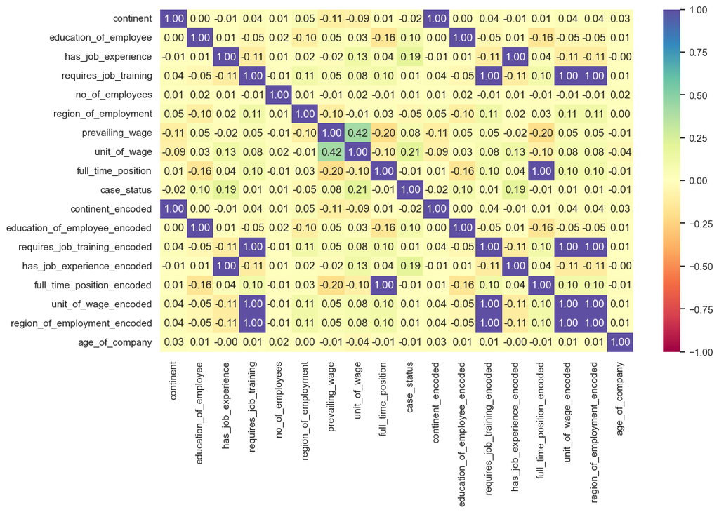

```python
cols_list = df.select_dtypes(include=np.number).columns.tolist()

plt.figure(figsize=(12, 7))
sns.heatmap(df[cols_list].corr(), annot=True, vmin=-1, vmax=1, fmt=".2f", cmap="Spectral")
plt.show()
```

**Data Preparataion for model building**

- We want to predict which visa will be certified.
- Before we proceed to build a model, we'll have to encode categorical features.
- We'll split the data into train and test to be able to evaluate the model that we build on the train data.
- When data (classification) exhibit a significant imbalance in the distribution of the target classes, it is good to use stratified sampling to ensure that relative class frequencies are approximately preserved in train and test sets.
- This is done by setting the stratify parameter to target variable in the train_test_split function.

```python
# Drop the 'case_status' column from the data and store the remaining columns in X
X = df.drop(['case_status'], axis=1)


# Assign the target variable 'case_status' to y
y = df["case_status"]

# Split the data into train and test sets in a 70:30 ratio
X_train, X_test, y_train, y_test = train_test_split(X, y, test_size=0.3, random_state=1, stratify=y)
```

```python
print("Shape of Training set : ", X_train.shape)
print("Shape of test set : ", X_test.shape)
print("Percentage of classes in training set:")
print(y_train.value_counts(normalize=True))
print("Percentage of classes in test set:")
print(y_test.value_counts(normalize=True))
```

```
Shape of Training set :  (17836, 17)
Shape of test set :  (7644, 17)
Percentage of classes in training set:
1    0.667919
0    0.332081
Name: case_status, dtype: float64
Percentage of classes in test set:
1    0.667844
0    0.332156
Name: case_status, dtype: float64
```

```python
print(X.head())
print()
print(y.head())
```

```
   continent  education_of_employee  has_job_experience  \
0          1                      2                   0
1          1                      3                   1
2          1                      0                   0
3          1                      0                   0
4          0                      3                   1

   requires_job_training  no_of_employees  region_of_employment  \
0                      0            14513                     4
1                      0             2412                     2
2                      1            44444                     4
3                      0               98                     4
4                      0             1082                     3

   prevailing_wage  unit_of_wage  full_time_position  continent_encoded  \
```

[output cut: 33 more lines]

```python
df.describe(include='all').T
```

|  | count | mean | std | min | 25% | 50% | 75% | max |
| --- | --- | --- | --- | --- | --- | --- | --- | --- |
| continent | 25480.0 | 1.539600 | 0.998292 | 0.0000 | 1.00 | 1.00 | 2.0000 | 5.00 |
| education_of_employee | 25480.0 | 1.488776 | 1.345155 | 0.0000 | 0.00 | 2.00 | 3.0000 | 3.00 |
| has_job_experience | 25480.0 | 0.580926 | 0.493417 | 0.0000 | 0.00 | 1.00 | 1.0000 | 1.00 |
| requires_job_training | 25480.0 | 0.115973 | 0.320199 | 0.0000 | 0.00 | 0.00 | 0.0000 | 1.00 |
| no_of_employees | 25480.0 | 5667.089207 | 22877.917453 | 11.0000 | 1022.00 | 2109.00 | 3504.0000 | 602069.00 |
| region_of_employment | 25480.0 | 2.593878 | 1.088376 | 0.0000 | 2.00 | 3.00 | 4.0000 | 4.00 |
| prevailing_wage | 25480.0 | 74455.814592 | 52815.942327 | 2.1367 | 34015.48 | 70308.21 | 107735.5125 | 319210.27 |
| unit_of_wage | 25480.0 | 2.728375 | 0.844267 | 0.0000 | 3.00 | 3.00 | 3.0000 | 3.00 |
| full_time_position | 25480.0 | 0.893760 | 0.308151 | 0.0000 | 1.00 | 1.00 | 1.0000 | 1.00 |
| case_status | 25480.0 | 0.667896 | 0.470977 | 0.0000 | 0.00 | 1.00 | 1.0000 | 1.00 |
| continent_encoded | 25480.0 | 1.539600 | 0.998292 | 0.0000 | 1.00 | 1.00 | 2.0000 | 5.00 |
| education_of_employee_encoded | 25480.0 | 1.488776 | 1.345155 | 0.0000 | 0.00 | 2.00 | 3.0000 | 3.00 |
| requires_job_training_encoded | 25480.0 | 0.115973 | 0.320199 | 0.0000 | 0.00 | 0.00 | 0.0000 | 1.00 |
| has_job_experience_encoded | 25480.0 | 0.580926 | 0.493417 | 0.0000 | 0.00 | 1.00 | 1.0000 | 1.00 |
| full_time_position_encoded | 25480.0 | 0.893760 | 0.308151 | 0.0000 | 1.00 | 1.00 | 1.0000 | 1.00 |
| unit_of_wage_encoded | 25480.0 | 0.115973 | 0.320199 | 0.0000 | 0.00 | 0.00 | 0.0000 | 1.00 |
| region_of_employment_encoded | 25480.0 | 0.115973 | 0.320199 | 0.0000 | 0.00 | 0.00 | 0.0000 | 1.00 |
| age_of_company | 25480.0 | 36.590071 | 42.366929 | 0.0000 | 11.00 | 19.00 | 40.0000 | 216.00 |

```python
X_train, X_test, y_train, y_test = train_test_split(X, y, test_size=.30, random_state=1,stratify=y)
print(X_train.shape, X_test.shape)
```

```
(17836, 17) (7644, 17)
```

*The data has been splitted into train and test sets in a 70:30 ratio.

**Model Building**

**Model evaluation criterion**

**Model can make wrong predictions as:**

- Model predicts that the visa application will get certified but in reality, the visa application should get denied.
- Model predicts that the visa application will not get certified but in reality, the visa application should get certified.

**Which case is more important?**

- Both the cases are important as:
- If a visa is certified when it had to be denied a wrong employee will get the job position while US citizens will miss the opportunity to work on that position.
- If a visa is denied when it had to be certified the U.S. will lose a suitable human resource that can contribute to the economy.

**How to reduce the losses?**

- F1 Score can be used a the metric for evaluation of the model, greater the F1 score higher are the chances of minimizing False Negatives and False Positives.
- We will use balanced class weights so that model focuses equally on both classes.

**We shall first create functions to calculate different metrics and confusion matrix so that we don't have to use the same code repeatedly for each model.**

- The model_performance_classification_sklearn function will be used to check the model performance of models.

The confusion_matrix_sklearn function will be used to plot the confusion matrix.

```python
# Import necessary libraries
from sklearn.metrics import accuracy_score, precision_score, recall_score, f1_score

def model_performance_classification_sklearn(predictors, target, model):
    """
    Function to compute different metrics to check classification model performance

    predictors: independent variables
    target: dependent variable
    model: classifier
    """

    # predicting using the independent variables
    pred = model.predict(predictors)

    acc = accuracy_score(target, pred)  # Compute Accuracy
    recall = recall_score(target, pred)  # Compute Recall
    precision = precision_score(target, pred)  # Compute Precision
    f1 = f1_score(target, pred)  # Compute F1-score

    print("Accuracy:", acc)
    print("Precision:", precision)
    print("Recall:", recall)
    print("F1-score:", f1)

    # Creating a dictionary of metrics for better readability
    perf_metrics = {"Accuracy": acc, "Precision": precision, "Recall": recall, "F1-score": f1}

    return perf_metrics
```

```python
def confusion_matrix_sklearn(model, predictors, target):
    """
    To plot the confusion matrix with percentages

    model: classifier
    predictors: independent variables
    target: dependent variable
    """
    y_pred = model.predict(predictors)
    cm = confusion_matrix(target, y_pred)
    labels = np.asarray(
        [
            ["{0:0.0f}".format(item) + "\n{0:.2%}".format(item / cm.sum())]
            for item in cm.flatten()
        ]
    ).reshape(cm.shape[0], cm.shape[1])

    plt.figure(figsize=(6, 4))
    sns.heatmap(cm, annot=labels, fmt="")
    plt.ylabel("True label")
    plt.xlabel("Predicted label")
    plt.show()
```

**create a function to get future importance of the model classifiers**

```python
def get_feature_importance(estimator, X_train):
    if isinstance(estimator, DecisionTreeClassifier):
        return pd.DataFrame(estimator.feature_importances_, columns=["Imp"], index=X_train.columns).sort_values(by='Imp', ascending=False)
    else:
        if hasattr(estimator, 'feature_importances_'):
            feature_importances = estimator.feature_importances_
        else:
            feature_importances = None
        return feature_importances

def plot_feature_importance(ensemble_method, X_train, y_train):
    ensemble_methods = [DecisionTreeClassifier, BaggingClassifier, RandomForestClassifier, AdaBoostClassifier, GradientBoostingClassifier, XGBClassifier, StackingClassifier]

    if type(ensemble_method) in ensemble_methods:
        ensemble_method.fit(X_train, y_train)

        feature_importance_dict = {}

        if isinstance(ensemble_method, StackingClassifier):
            for name, est in ensemble_method.named_estimators_.items():
                feature_importances = get_feature_importance(est, X_train)
                if feature_importances is not None:
                    for i, imp in enumerate(feature_importances):
                        if X_train.columns[i] in feature_importance_dict:
                            feature_importance_dict[X_train.columns[i]] += imp
                        else:
                            feature_importance_dict[X_train.columns[i]] = imp
        else:
            feature_importances = get_feature_importance(ensemble_method, X_train)
            if feature_importances is not None:
                for i, imp in enumerate(feature_importances):
                    if X_train.columns[i] in feature_importance_dict:
                        feature_importance_dict[X_train.columns[i]] += imp
                    else:
                        feature_importance_dict[X_train.columns[i]] = imp

        total = sum(feature_importance_dict.values())
        normalized_feature_imp = {k: v / total for k, v in feature_importance_dict.items()}

        feature_importance_df = pd.DataFrame(list(normalized_feature_imp.items()), columns=['Feature', 'Importance'])
        feature_importance_df = feature_importance_df.sort_values('Importance', ascending=False)

        if isinstance(ensemble_method, (DecisionTreeClassifier, BaggingClassifier, RandomForestClassifier)):
            importances_df = pd.DataFrame(ensemble_method.feature_importances_.reshape(-1, 1), columns=["Imp"], index=X_train.columns[:len(ensemble_method.feature_importances_)])

        print(importances_df)

        plt.figure(figsize=(12,12))
        plt.barh(range(len(feature_importance_df)), feature_importance_df['Importance'], color='violet', align='center')
        plt.yticks(range(len(feature_importance_df)), feature_importance_df['Feature'])
        plt.xlabel('Relative Importance')
        plt.title(f'Feature Importances for {type(ensemble_method).__name__}')
        plt.show()
    else:
        print("Ensemble method not supported for feature importance analysis.")
```

**Model Building**

**Building Bagging and Boosting Models**

**Decision Tree Classifier - Model Building and Hyperparameter Tuning**

```python
dtree = DecisionTreeClassifier(random_state=1) ## the code to define decision tree classifier with random state = 1
```

```python
dtree.fit(X_train,y_train) ## the code to fit decision tree classifier on the train data
```

```
DecisionTreeClassifier(random_state=1)
```

**Checking model performance on training set**

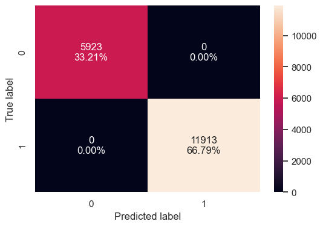

```python
# Call the confusion_matrix_sklearn function with the correct arguments
confusion_matrix_sklearn(dtree, X_train, y_train)
```

- True Positives (Actual 1, Predicted 1):

The value 11913 in the bottom-right cell represents the number of true positives. This indicates that the model correctly predicted 11913 cases where the visa was actually approved (1) as approved (1).

The top-right cell with the value 0 denotes the number of false positives. These are cases where the model incorrectly predicted a visa approval (1) whe is actually denied(0).

The bottom-left cell with the value 0 represents the number of false negatives. This indicates instances where the model incorrectly predicted a visa denial (0) when the visa was actually approved (1).

```python
# Check performance on the training data
decision_tree_perf_train = model_performance_classification_sklearn(X_train, y_train, dtree)

print("Decision Tree Model Performance on Training Data:")
print(decision_tree_perf_train)
```

```
Accuracy: 1.0
Precision: 1.0
Recall: 1.0
F1-score: 1.0
Decision Tree Model Performance on Training Data:
{'Accuracy': 1.0, 'Precision': 1.0, 'Recall': 1.0, 'F1-score': 1.0}
```

- Perfect Performance: The accuracy, precision, recall, and F1-score values of 1.0 suggest that the model predicts all classes (both positive and negative) in the training data correctly. This indicates that the model is making accurate predictions with no errors in classification.
- The model is potentially overfitting the train set.